# 3 Diff-in-Diff

## 3.1 Introduction

This week we will start talking about Causal Inference in R. You will have already seen the theoretical and mathematical parts with Brenda in the lecture. This script is supposed to initiate you to the practical part of Causal Inference.

This session will show you how to :

1. Prepare data for Causal Inference
2. Perform a simple Diff-in-Diff analysis in R
3. Interpret the results of a Diff-in-Diff analysis in R

```r
library(haven)
library(knitr)
library(modelsummary)
library(scales)
library(tidyverse)
```

## 3.2 Diff-in-Diff

For the first example on Diff-in-Diff I am going to use the code written by the brilliant [Rohan Alexander](https://rohanalexander.com/) who has written one of the (if not *the*) best introduction to Data Analysis in R which you can find [here](https://tellingstorieswithdata.com/). Furthermore, the example he uses is a paper written by [Charles Angelucci](https://sites.google.com/site/charlesangelucci/) and [Julia Cagé](https://juliacage.com/fr/) who you probably know already.

```r
set.seed(853)

simulated_diff_in_diff <-
  tibble(
    person = rep(c(1:1000), times = 2),
    time = c(rep(0, times = 1000), rep(1, times = 1000)),
    treat_group = rep(sample(x = 0:1, size = 1000, replace = TRUE ), times = 2)
    ) |>
  mutate(
    treat_group = as.factor(treat_group),
    time = as.factor(time)
  )

simulated_diff_in_diff <-
  simulated_diff_in_diff |>
  rowwise() |>
  mutate(
    serve_speed = case_when(
      time == 0 & treat_group == 0 ~ rnorm(n = 1, mean = 5, sd = 1),
      time == 1 & treat_group == 0 ~ rnorm(n = 1, mean = 6, sd = 1),
      time == 0 & treat_group == 1 ~ rnorm(n = 1, mean = 8, sd = 1),
      time == 1 & treat_group == 1 ~ rnorm(n = 1, mean = 14, sd = 1)
    )
  )

simulated_diff_in_diff
```

```
# A tibble: 2,000 × 4
# Rowwise:
   person time  treat_group serve_speed
    <int> <fct> <fct>             <dbl>
 1      1 0     0                  4.43
 2      2 0     1                  6.96
 3      3 0     1                  7.77
 4      4 0     0                  5.31
 5      5 0     0                  4.09
 6      6 0     0                  4.85
 7      7 0     0                  6.43
 8      8 0     0                  5.77
 9      9 0     1                  6.13
10     10 0     1                  7.32
# ℹ 1,990 more rows
```

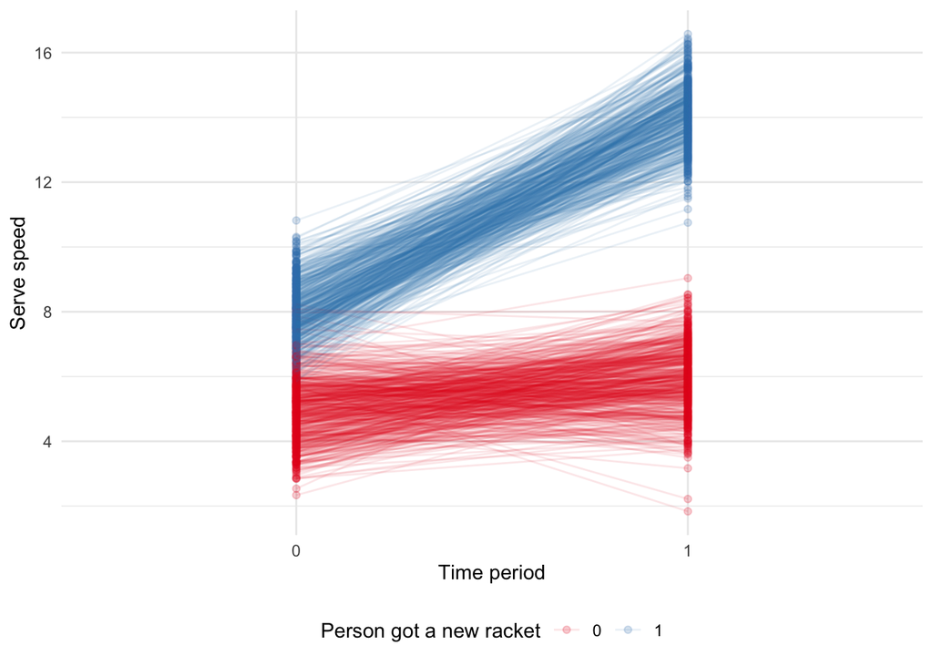

```r
simulated_diff_in_diff |>
  ggplot(aes(x = time, y = serve_speed, color = treat_group)) +
  geom_point(alpha = 0.2) +
  geom_line(aes(group = person), alpha = 0.1) +
  theme_minimal() +
  labs(x = "Time period", y = "Serve speed", color = "Person got a new racket") +
  scale_color_brewer(palette = "Set1") +
  theme(legend.position = "bottom")
```

The paper is called “Newspapers in Times of Low Advertising Revenues” (Angelucci and Cagé 2019) and follows a difference-in-difference analysis and it also comes with replication material which means that we can try to emulate their results.

In 1967, the French government introduced advertisements on French TV programs. This led to a decrease in advertising revenues for newspapers all over France. The idea is therefore to understand if and how the introduction of ads on TV affected the ad revenues for newspapers, both local and national ones, in France. They use a difference-in-difference approach to estimate the effect of the introduction of advertising on the advertising revenues of newspapers. Thus, the treatment is…? Exactly, the introduction of ads on TV. Angelucci and Cagé argue that national newspapers were more affected by this change than local newspapers. They have many more hypotheses which they test in this paper, but for now we will focus on this one. As mentioned above, their [data is available](https://www.openicpsr.org/openicpsr/project/116438/version/V1/view) and we can use it to replicate their results. You need to sign up, to get it.

```r
newspapers <- read_dta("data/Angelucci_Cage_AEJMicro_dataset.dta")
```

Next we will have to do some minor data management. Fortunately enough, this replication material is already pretty clean and we do not have to `mutate()` or `filter()` our way around too much. The only thing we actually have to do, is to convert some variables into factors and to create a new variable which is the ratio of advertising revenue over circulation. Here I specify the argument `across()` again of the `mutate()` function and within it, I give a vector `c()` containing all the variables that should be transformed to factors.

Here is a brief explanation of the variables in the dataset:

```r
newspapers <-
  newspapers |>
  select(
    year, id_news, after_national, local, national, ra_cst, ps_cst, qtotal
    ) |>
  mutate(ra_cst_div_qtotal = ra_cst / qtotal,
         after_national =  if_else(year >= 1967, 1, 0),
         after_national_placebo = if_else(year >= 1966, 1, 0),
         across(c(id_news, local, national, after_national), as.factor),
         year = as.factor(year)) |>
  rename()

newspapers
```

```
# A tibble: 1,196 × 10
   year  id_news after_national local national    ra_cst ps_cst  qtotal
   <fct> <fct>   <fct>          <fct> <fct>        <dbl>  <dbl>   <dbl>
 1 1960  1       0              1     0         52890272   2.29  94478.
 2 1961  1       0              1     0         56601060   2.20  96289.
 3 1962  1       0              1     0         64840752   2.13  97313.
 4 1963  1       0              1     0         70582944   2.43 101068.
 5 1964  1       0              1     0         74977888   2.35 102103.
 6 1965  1       0              1     0         74438248   2.29 105169.
 7 1966  1       0              1     0         81383000   2.31 126235.
 8 1967  1       1              1     0         80263152   2.88 128667.
 9 1968  1       1              1     0         87165704   3.45 131824.
10 1969  1       1              1     0        102596384   3.28 132417.
# ℹ 1,186 more rows
# ℹ 2 more variables: ra_cst_div_qtotal <dbl>, after_national_placebo <dbl>
```